# Project Foundations for Data Science: FoodHub Data Analysis

### Context

The number of restaurants in New York is increasing day by day. Lots of students and busy professionals rely on those restaurants due to their hectic lifestyles. Online food delivery service is a great option for them. It provides them with good food from their favorite restaurants. A food aggregator company FoodHub offers access to multiple restaurants through a single smartphone app.

The app allows the restaurants to receive a direct online order from a customer. The app assigns a delivery person from the company to pick up the order after it is confirmed by the restaurant. The delivery person then uses the map to reach the restaurant and waits for the food package. Once the food package is handed over to the delivery person, he/she confirms the pick-up in the app and travels to the customer's location to deliver the food. The delivery person confirms the drop-off in the app after delivering the food package to the customer. The customer can rate the order in the app. The food aggregator earns money by collecting a fixed margin of the delivery order from the restaurants.

### Objective

The food aggregator company has stored the data of the different orders made by the registered customers in their online portal. They want to analyze the data to get a fair idea about the demand of different restaurants which will help them in enhancing their customer experience. Suppose you are hired as a Data Scientist in this company and the Data Science team has shared some of the key questions that need to be answered. Perform the data analysis to find answers to these questions that will help the company to improve the business.

### Data Description

The data contains the different data related to a food order. The detailed data dictionary is given below.

### Data Dictionary

- order_id: Unique ID of the order
- customer_id: ID of the customer who ordered the food
- restaurant_name: Name of the restaurant
- cuisine_type: Cuisine ordered by the customer
- cost: Cost of the order
- day_of_the_week: Indicates whether the order is placed on a weekday or weekend (The weekday is from Monday to Friday and the weekend is Saturday and Sunday)
- rating: Rating given by the customer out of 5
- food_preparation_time: Time (in minutes) taken by the restaurant to prepare the food. This is calculated by taking the difference between the timestamps of the restaurant's order confirmation and the delivery person's pick-up confirmation.
- delivery_time: Time (in minutes) taken by the delivery person to deliver the food package. This is calculated by taking the difference between the timestamps of the delivery person's pick-up confirmation and drop-off information

### Let us start by importing the required libraries

```python
# import libraries for data manipulation
import numpy as np
import pandas as pd

# import libraries for data visualization
import matplotlib.pyplot as plt
import seaborn as sns

# To ignore warnings
import warnings
warnings.filterwarnings("ignore")
```

### 1.0.6 Let's setting up jupyter in order to be able to see all columns and rows

```python
pd.set_option("display.max_rows", None) # We dont put a limit in the amount of rows that should be display
pd.set_option("display.max_columns", 30) # We allow the visualisation of up to 30 variables
pd.set_option("display.width", None) #  seting display width to none
pd.set_option("display.max_colwidth", None) # Display the full width of column without truncating them
```

### Understanding the structure of the data

```python
# uncomment and run the following lines for Google Colab
# from google.colab import drive
# drive.mount('/content/drive')
```

```python
# read the data
df = pd.read_csv('foodhub_order.csv')
# returns the first 20 rows
df.head(20)
```

|  | order_id | customer_id | restaurant_name | cuisine_type | cost_of_the_order | day_of_the_week | rating | food_preparation_time | delivery_time |
| --- | --- | --- | --- | --- | --- | --- | --- | --- | --- |
| 0 | 1477147 | 337525 | Hangawi | Korean | 30.75 | Weekend | Not given | 25 | 20 |
| 1 | 1477685 | 358141 | Blue Ribbon Sushi Izakaya | Japanese | 12.08 | Weekend | Not given | 25 | 23 |
| 2 | 1477070 | 66393 | Cafe Habana | Mexican | 12.23 | Weekday | 5 | 23 | 28 |
| 3 | 1477334 | 106968 | Blue Ribbon Fried Chicken | American | 29.20 | Weekend | 3 | 25 | 15 |
| 4 | 1478249 | 76942 | Dirty Bird to Go | American | 11.59 | Weekday | 4 | 25 | 24 |
| 5 | 1477224 | 147468 | Tamarind TriBeCa | Indian | 25.22 | Weekday | 3 | 20 | 24 |
| 6 | 1477894 | 157711 | The Meatball Shop | Italian | 6.07 | Weekend | Not given | 28 | 21 |
| 7 | 1477859 | 89574 | Barbounia | Mediterranean | 5.97 | Weekday | 3 | 33 | 30 |
| 8 | 1477174 | 121706 | Anjappar Chettinad | Indian | 16.44 | Weekday | 5 | 21 | 26 |
| 9 | 1477311 | 39705 | Bukhara Grill | Indian | 7.18 | Weekday | 5 | 29 | 26 |
| 10 | 1477895 | 143926 | Big Wong Restaurant _¤¾Ñ¼ | Chinese | 5.92 | Weekday | Not given | 34 | 28 |
| 11 | 1478437 | 221206 | Empanada Mama (closed) | Mexican | 8.10 | Weekend | 5 | 23 | 22 |
| 12 | 1476966 | 129969 | Blue Ribbon Fried Chicken | American | 24.30 | Weekend | 5 | 23 | 17 |
| 13 | 1477449 | 104548 | Pylos | Mediterranean | 11.30 | Weekend | 3 | 24 | 23 |
| 14 | 1478198 | 62667 | Lucky's Famous Burgers | American | 12.13 | Weekday | Not given | 23 | 30 |
| 15 | 1477414 | 66222 | Shake Shack | American | 16.20 | Weekend | 5 | 33 | 25 |
| 16 | 1477486 | 104555 | Sushi of Gari | Japanese | 16.98 | Weekend | Not given | 30 | 16 |
| 17 | 1477373 | 139885 | Blue Ribbon Sushi Izakaya | Japanese | 33.03 | Weekend | Not given | 21 | 22 |
| 18 | 1477138 | 47280 | RedFarm Hudson | Chinese | 14.12 | Weekend | 4 | 25 | 24 |
| 19 | 1477354 | 67487 | Blue Ribbon Sushi | Japanese | 16.20 | Weekend | 4 | 35 | 26 |

#### Observations:

The DataFrame has 9 columns as mentioned in the Data Dictionary. Data in each row corresponds to the order placed by a customer.

### **Question 1:** How many rows and columns are present in the data?

```python
# Number of rows and columns in our DataFrame
df.shape
print(f"Our DataFrame contains {df.shape[0]} rows and {df.shape[1]} columns")
```

```
Our DataFrame contains 1898 rows and 9 columns
```

#### Observations:

As mentionned above we can see that our DataFrame contains effectively 9 columns and 1898 rows

### **Question 2:** What are the datatypes of the different columns in the dataset?

```python
# Datatypes of the different columns
df.info()
```

```
<class 'pandas.core.frame.DataFrame'>
RangeIndex: 1898 entries, 0 to 1897
Data columns (total 9 columns):
 #   Column                 Non-Null Count  Dtype
---  ------                 --------------  -----
 0   order_id               1898 non-null   int64
 1   customer_id            1898 non-null   int64
 2   restaurant_name        1898 non-null   object
 3   cuisine_type           1898 non-null   object
 4   cost_of_the_order      1898 non-null   float64
 5   day_of_the_week        1898 non-null   object
 6   rating                 1898 non-null   object
 7   food_preparation_time  1898 non-null   int64
 8   delivery_time          1898 non-null   int64
dtypes: float64(1), int64(4), object(4)
memory usage: 133.6+ KB
```

#### Observations:

Our DataFrame contains 09 columns. We have tree differents datatypes: integer, strings and float.

- Columns order_id, customer_id, food_preparation_time and delivery_time are all integer datatypes
- Columns restaurant_name, cuisine type, rating and day_of_the_week are all string datatypes
- Columns cost_of_the_order is a float datatype

### **Question 3:** Are there any missing values in the data? If yes, treat them using an appropriate method

```python
# Checking of missing value
df.isnull().head(5) # Here we use the 'isnull()' function to have a global view of our data about missing value
```

|  | order_id | customer_id | restaurant_name | cuisine_type | cost_of_the_order | day_of_the_week | rating | food_preparation_time | delivery_time |
| --- | --- | --- | --- | --- | --- | --- | --- | --- | --- |
| 0 | False | False | False | False | False | False | False | False | False |
| 1 | False | False | False | False | False | False | False | False | False |
| 2 | False | False | False | False | False | False | False | False | False |
| 3 | False | False | False | False | False | False | False | False | False |
| 4 | False | False | False | False | False | False | False | False | False |

```python
df.isnull().sum() # Here we add the sum() funtion to sum up the missing value in respect to each column
```

```
order_id                 0
customer_id              0
restaurant_name          0
cuisine_type             0
cost_of_the_order        0
day_of_the_week          0
rating                   0
food_preparation_time    0
delivery_time            0
dtype: int64
```

#### Observations:

DataFrame don't have missing values. all the variables are filled with values. The rating column has rows that haven't been rated. I decide to not treat them since they are too much. I will maybe replace them later with 0 to do some analysis.

### **Question 4:** Check the statistical summary of the data. What is the minimum, average, and maximum time it takes for food to be prepared once an order is placed?

```python
# statistical summary of the data
df.describe().T # The function describe() with the transpose function give us  clear view of our statistic
```

|  | count | mean | std | min | 25% | 50% | 75% | max |
| --- | --- | --- | --- | --- | --- | --- | --- | --- |
| order_id | 1898.0 | 1.477496e+06 | 548.049724 | 1476547.00 | 1477021.25 | 1477495.50 | 1.477970e+06 | 1478444.00 |
| customer_id | 1898.0 | 1.711685e+05 | 113698.139743 | 1311.00 | 77787.75 | 128600.00 | 2.705250e+05 | 405334.00 |
| cost_of_the_order | 1898.0 | 1.649885e+01 | 7.483812 | 4.47 | 12.08 | 14.14 | 2.229750e+01 | 35.41 |
| food_preparation_time | 1898.0 | 2.737197e+01 | 4.632481 | 20.00 | 23.00 | 27.00 | 3.100000e+01 | 35.00 |
| delivery_time | 1898.0 | 2.416175e+01 | 4.972637 | 15.00 | 20.00 | 25.00 | 2.800000e+01 | 33.00 |

#### Observations:

We have the value of mean, count, standart deviation, minimum, maximum and interquartile ranges.

25% of all food preparations were completed within 23 minutes or less 75% of food preparations were completed within 31 minutes or less Only 25% of all food preparations took longer than 31 minutes with a max value of preparation reaching 35 minutes.

- For cost_of_the_order, which refer to the amount of money spent on a particular order, we have also 1898 entries. The mean cost of an order is approximatively 16.50 euros with a standard deviation of around 7.48 euros

25% of all orders have a cost of 12.08 euros or less. 75% of all orders have a cost of 22.30 euros or less and just 25% of all each order have cost more than 22.30 euros The minimun cost of an order is 4.47 euros, and the maximum cost is 35.41 euros.

### **Question 5:** How many orders are not rated?

```python
# We create a DataFrame with two columns: rating and not rating
Frame = pd.DataFrame({
    "Rating": [df["rating"][df["rating"] == "Not given"].count()],
    "Not_Rating": [df["rating"][df["rating"] != "Not given"].count()]
})

Frame
```

[output not shown]

### Exploratory Data Analysis (EDA)

### **Question 6:** Explore all the variables and provide observations on their distributions. (Generally, histograms, boxplots, countplots, etc. are used for univariate exploration)

```python
day = df["day_of_the_week"].nunique() # To see how much unique value we have in the variable day of the week.
day
```

```
2
```

```python
rate = df["rating"].nunique() # To see how much unique value we have in the variable rating.
rate
```

```
4
```

```python
# Here we convert some variable into categorical variable in order to display a count plot.

df["day_of_the_week"] = df["day_of_the_week"].astype("category")
df["rating"] = df["rating"].astype("category")

df.info() # Checking the info of the data to see whether or not the change has been done.
```

```
<class 'pandas.core.frame.DataFrame'>
RangeIndex: 1898 entries, 0 to 1897
Data columns (total 9 columns):
 #   Column                 Non-Null Count  Dtype
---  ------                 --------------  -----
 0   order_id               1898 non-null   int64
 1   customer_id            1898 non-null   int64
 2   restaurant_name        1898 non-null   object
 3   cuisine_type           1898 non-null   object
 4   cost_of_the_order      1898 non-null   float64
 5   day_of_the_week        1898 non-null   category
 6   rating                 1898 non-null   category
 7   food_preparation_time  1898 non-null   int64
 8   delivery_time          1898 non-null   int64
dtypes: category(2), float64(1), int64(4), object(2)
memory usage: 108.0+ KB
```

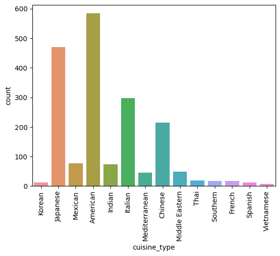

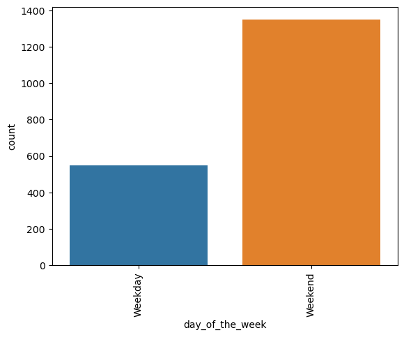

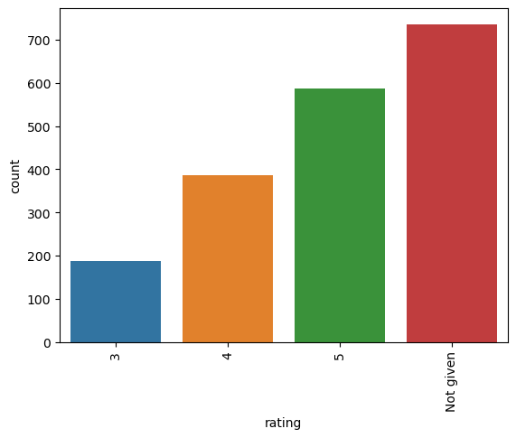

```python
arr = ["cuisine_type", "day_of_the_week", "rating"] # creating an array of variable
for i in arr: # iterate over the arr and create corresponding count plot
    sns.countplot(data=df, x=i) # using countplot from seaborn library
    plt.xticks(rotation = 90) # rotating the label of the x axis to 90 degree
    plt.show()  # This line is added to display each plot separately
```

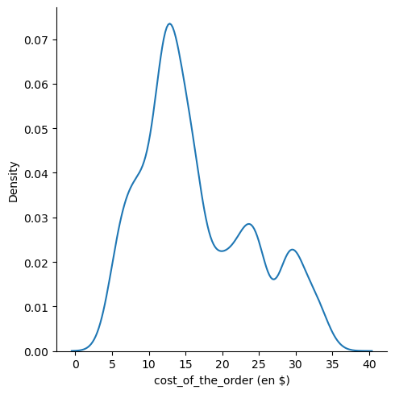

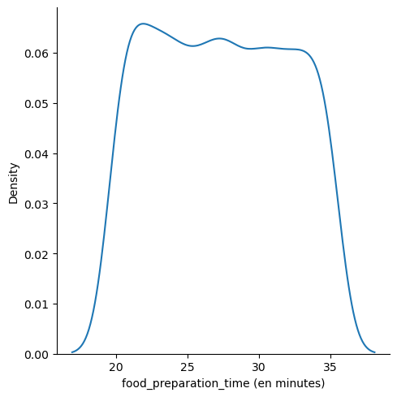

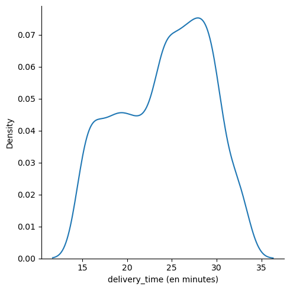

```python
arry = ["cost_of_the_order", "food_preparation_time", "delivery_time"] # creating an array of variables
for i in arry: # iterate over the array and plot a displot from the seaborm library
    sns.displot(data=df, x=i, kind="kde")
    plt.xlabel(f"{i} (en $)" if i == "cost_of_the_order" else f"{i} (en minutes)")


plt.show()
```

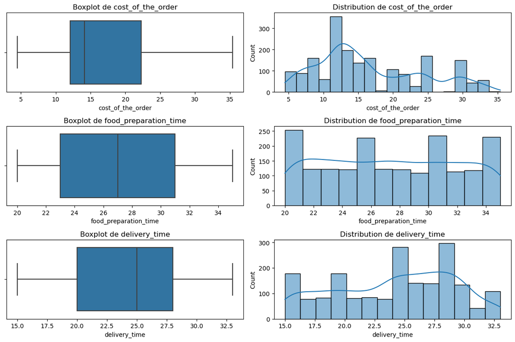

```python
# listing variables to visualise
variables = ["cost_of_the_order", "food_preparation_time", "delivery_time"]

# Creation of sub-plots for each variable
fig, axs = plt.subplots(len(variables), 2, figsize=(12, 8))

# iterate on each variable
for i, variable in enumerate(variables):
    # Boxplot
    sns.boxplot(x=df[variable], ax=axs[i, 0])
    axs[i, 0].set_title(f'Boxplot de {variable}')

    # Displot (Histogram with estimation of density)
    sns.histplot(data=df, x=variable, kde=True, ax=axs[i, 1])
    axs[i, 1].set_title(f'Distribution de {variable}')

# Ajustement of layout
plt.tight_layout()
plt.show()
```

### **Question 7**: Which are the top 5 restaurants in terms of the number of orders received?

```python
# extract the two columns order id and restaurant name
top = df[["order_id", "restaurant_name"]]
top.head(5)
```

|  | order_id | restaurant_name |
| --- | --- | --- |
| 0 | 1477147 | Hangawi |
| 1 | 1477685 | Blue Ribbon Sushi Izakaya |
| 2 | 1477070 | Cafe Habana |
| 3 | 1477334 | Blue Ribbon Fried Chicken |
| 4 | 1478249 | Dirty Bird to Go |

```python
# grouping our data by restaurant and we count the number of entries
top5 = top.groupby("restaurant_name")["order_id"].count()
top5.head(5)
```

```
restaurant_name
'wichcraft         1
12 Chairs          4
5 Napkin Burger    5
67 Burger          1
Alidoro            1
Name: order_id, dtype: int64
```

```python
# sorting our data by ascending number
top5 = top5.sort_values(ascending=False).head(5)
top5
```

```
restaurant_name
Shake Shack                  219
The Meatball Shop            132
Blue Ribbon Sushi            119
Blue Ribbon Fried Chicken     96
Parm                          68
Name: order_id, dtype: int64
```

### **Question 8**: Which is the most popular cuisine on weekends?

```python
# filtering our DataFrae to have only weekends in our day of the week variable
weekend_df = df.loc[df["day_of_the_week"].isin(["Weekend"])] # I use loc function to acceess rows in the dataframe by name and isin to verify in each row  if my condition is verify
weekend_df.head(2)
```

|  | order_id | customer_id | restaurant_name | cuisine_type | cost_of_the_order | day_of_the_week | rating | food_preparation_time | delivery_time |
| --- | --- | --- | --- | --- | --- | --- | --- | --- | --- |
| 0 | 1477147 | 337525 | Hangawi | Korean | 30.75 | Weekend | Not given | 25 | 20 |
| 1 | 1477685 | 358141 | Blue Ribbon Sushi Izakaya | Japanese | 12.08 | Weekend | Not given | 25 | 23 |

```python
week_group = weekend_df.groupby("cuisine_type").count()["day_of_the_week"]
week_group
```

```
cuisine_type
American          415
Chinese           163
French             13
Indian             49
Italian           207
Japanese          335
Korean             11
Mediterranean      32
Mexican            53
Middle Eastern     32
Southern           11
Spanish            11
Thai               15
Vietnamese          4
Name: day_of_the_week, dtype: int64
```

```python
max_restaurant = week_group.idxmax()
print("The restaurant with the maximum count during the weekend is:", max_restaurant)
```

```
The restaurant with the maximum count during the weekend is: American
```

#### Observations:

The restaurant with the maximum count during the weekend is: American

### **Question 9**: What percentage of the orders cost more than 20 dollars?

```python
# checking the stats of the variable dollars
stat_order = df['cost_of_the_order'].describe().T
stat_order
```

```
count    1898.000000
mean       16.498851
std         7.483812
min         4.470000
25%        12.080000
50%        14.140000
75%        22.297500
max        35.410000
Name: cost_of_the_order, dtype: float64
```

```python
import scipy.stats as sci # Package for make probability analysis
from scipy.stats import norm # I will use the normal distribution from the packqge scipy
mu = 16.498851
std = 7.483812
percent_above_20 = 1 - norm.cdf(20, mu, std)
percent_above_20
```

```
0.3199532148241405
```

#### Observations:

The percentage of the orders cost more than 20 dollars is around 30% or pob of 0.3

### **Question 10**: What is the mean order delivery time?

```python
mean_delivery_time = np.mean(df["delivery_time"]) # using the function mean from the package numpu
rounded_mean_delivery_time = round(mean_delivery_time, 2) # rounding the result to 2 number after the dot.
rounded_mean_delivery_time
```

```
24.16
```

#### Observations:

The mean order delivery time is 24.16 minutes

### **Question 11:** The company has decided to give 20% discount vouchers to the top 3 most frequent customers. Find the IDs of these customers and the number of orders they placed

```python
pik = df[['customer_id', 'order_id']] # Extrating the two variables customer id and order id
group_pik = pik.groupby('customer_id')['order_id'].count() # grouping them with customer id and counting the number of order
sort_pik = group_pik.sort_values(ascending=False).head(3) # sorting the data with descending order.
sort_pik # display the result
```

```
customer_id
52832    13
47440    10
83287     9
Name: order_id, dtype: int64
```

### Observations:

The top most customer with the number of orders they placed are:

- **52832**: Thirteen times
- **47440**: Ten times
- **83287**: Nine tmes

### 10.2.3 Multivariate Analysis

### **Question 12**: Perform a multivariate analysis to explore relationships between the important variables in the dataset. (It is a good idea to explore relations between numerical variables as well as relations between numerical and categorical variables)

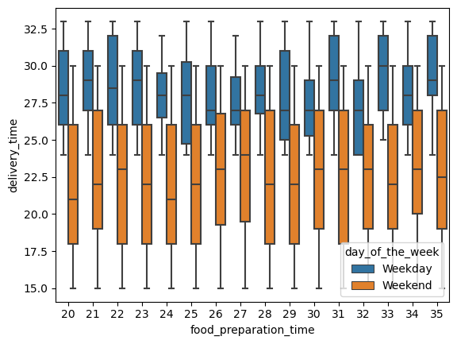

```python
scat = sns.boxplot(data = df, x = "food_preparation_time", y = "delivery_time", hue ="day_of_the_week") # plotting the food preparation time and delivery time in respect to day of the week
plt.show()
```

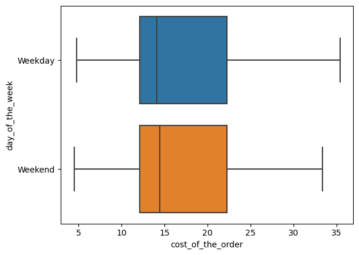

```python
scat2 = sns.boxplot(data = df, x = "cost_of_the_order", y ="day_of_the_week") # checking the relation between cost of the order and day of the week
scat2
```

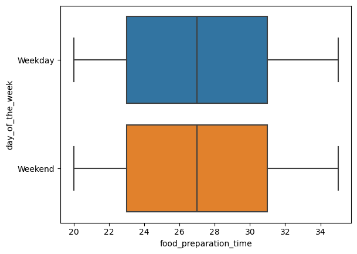

```python
preparation_time = sns.boxplot(data = df, x = "food_preparation_time", y ="day_of_the_week")  # checking the relation between food preparation time and day of the week
preparation_time
```

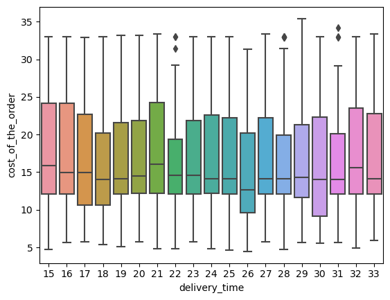

```python
scat2 = sns.boxplot(data = df, x = "delivery_time", y ="cost_of_the_order")  # checking the relation between delivery time and cost of the order
```

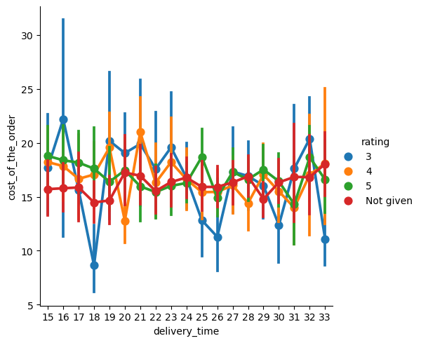

```python
cat = sns.catplot(data = df, x = "delivery_time", y ="cost_of_the_order", hue = "rating", kind = "point") # plotting the delivery time and dcost of order in respect to rating
```

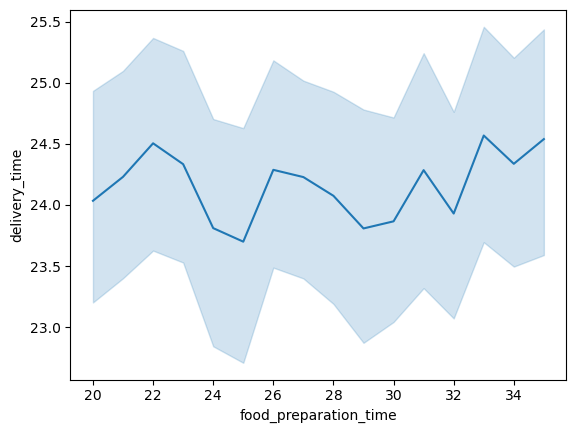

```python
displot = sns.lineplot(data = df, x ='food_preparation_time', y= 'delivery_time')
```

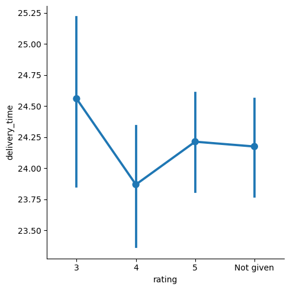

```python
displot = sns.catplot(data = df, x ='rating', y= 'delivery_time', kind ='point') # checking the relation between rating and delivery time
```

```python
# Create a copy of the DataFrame to avoid modifying the original
promotion_criteria = df.copy()

# Replace "Not given" with '0' in the rating column (I have converted the variable into string to be able to replace that value)
promotion_criteria['rating'] = promotion_criteria['rating'].astype(str).replace('Not given', '0')

# Convert the "rating" column back to numeric data type
promotion_criteria['rating'] = pd.to_numeric(promotion_criteria['rating'])

# Group by "restaurant_name" and calculate the count and mean of ratings
promotion_group = promotion_criteria.groupby('restaurant_name')['rating'].agg(['count', 'mean'])

# Create a DataFrame to store the count and mean of ratings per restaurant
FramePromotion = pd.DataFrame({
    'count': promotion_group['count'],
    'mean': promotion_group['mean']
})

FramePromotion.head()
```

| restaurant_name | count | mean |
| --- | --- | --- |
| 'wichcraft | 1 | 5.00 |
| 12 Chairs | 4 | 2.25 |
| 5 Napkin Burger | 5 | 1.60 |
| 67 Burger | 1 | 5.00 |
| Alidoro | 1 | 0.00 |

```python
ranges = []

for index, row in df.iterrows():
    if row['cost_of_the_order'] > 20:
        row['cost_of_the_order'] = row['cost_of_the_order'] * 25 /100
    elif row['cost_of_the_order'] > 5:
        row['cost_of_the_order'] = row['cost_of_the_order'] * 0.15
    else:
        pass  # If rating <= 5 or NaN, do nothing

    ranges.append(row)

# Convert the list of modified rows back to a DataFrame
modified_df = pd.DataFrame(ranges)

# Display the modified DataFrame
modified_df.rename(columns={'cost_of_the_order': 'cost_after_charges'}, inplace=True)
modified_df.head()
```

|  | order_id | customer_id | restaurant_name | cuisine_type | cost_after_charges | day_of_the_week | rating | food_preparation_time | delivery_time |
| --- | --- | --- | --- | --- | --- | --- | --- | --- | --- |
| 0 | 1477147 | 337525 | Hangawi | Korean | 7.6875 | Weekend | Not given | 25 | 20 |
| 1 | 1477685 | 358141 | Blue Ribbon Sushi Izakaya | Japanese | 1.8120 | Weekend | Not given | 25 | 23 |
| 2 | 1477070 | 66393 | Cafe Habana | Mexican | 1.8345 | Weekday | 5 | 23 | 28 |
| 3 | 1477334 | 106968 | Blue Ribbon Fried Chicken | American | 7.3000 | Weekend | 3 | 25 | 15 |
| 4 | 1478249 | 76942 | Dirty Bird to Go | American | 1.7385 | Weekday | 4 | 25 | 24 |

### **Question 15:** The company wants to analyze the total time required to deliver the food. What percentage of orders take more than 60 minutes to get delivered from the time the order is placed? (The food has to be prepared and then delivered)

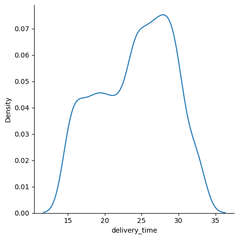

```python
sns.displot(data = df, x= 'delivery_time', kind ='kde') # Checking the distribution
plt.show()
```

```python
# Write the code here
from scipy.stats import uniform # using of uniform distribution
mu = 2.416175e+01
std = 4.972637
percent_above_20 = 1 - uniform.cdf(60, mu, std)
percent_above_20
```

```
0.0
```

### **Question 16:** The company wants to analyze the delivery time of the orders on weekdays and weekends. How does the mean delivery time vary during weekdays and weekends?

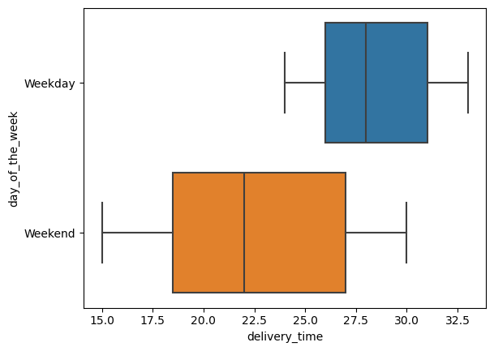

```python
# Write the code here
Delivery_time = sns.boxplot(data = df, x = "delivery_time", y ="day_of_the_week")
Delivery_time
```

#### Observations:

- The mean delivery time in weekday is around 28 minutes
- The mean delivery time in weekend is around 23 minutes

### Recommendations:

- Optimize Food Preparation Time:
- Improve Delivery Efficiency
- Enhance Overall Customer Experience
- Monitor and Iterate (Continuous improvement)